# Análisis de Datos - Morazán y Luisiana

Hector Corrales

3/23/2021

### **I. Data**

#### Se recibieron archivos conteniendo información de despachos y registros de clientes para dos estaciones:

#### **Morazan**

##### Base de 9,788 registros de cliente.

##### 65,536 despachos entre Septiembre 2019 y Julio 2020.

#### **Luisiana**

##### Base de 2,766 registros de cliente.

##### 65,536 despachos entre Agosto 2020 y Marzo 2021.

### **II. Calidad y Tratamiento**

#### **Despachos:** La calidad de la data existente es alta y sigue un formato estándar. No obstante, existen variables útiles para el análisis que no han sido incluidas. En particular: (i) tipo de combustible, (ii) litros en el despacho, (iii) precio del combustible al momento de la venta y si la venta fue pagada o hecha al crédito.

#### **Clientes:** La calidad de la base de datos de clientes es baja y con los siguientes puntos débiles.

#### Falta de Campo Llave.

#### Formato libre en introducción de RTN.

#### Poca data sobre cel, email, dirección. (aprox. 3%)

#### Consulta sobre el origen y funcion de los campos de crédito y retención.

### **III. Unión y Limpieza de Tablas de Despacho**

#### Se usaron 2 tablas de cada estación: “HInvoice”, la cual contiene las transacciones/despachos individuales, y “Clientes”, o la base de registros de clientes. Se seleccionaron los campos relevantes de cada una y se unieron ambas tablas usando el ID de Cliente como la llave. Para dar el siguiente resultado:

#### **Tabla Maestra**

```
## # A tibble: 6 x 11
##   Cajero CliID   InvoiceNumber VentaTotal SysDate             StoreId CAI
##   <chr>  <chr>           <dbl>      <dbl> <dttm>                <dbl> <chr>
## 1 2      999999~         41889       100  2019-10-31 12:34:03       0 406003-4D~
## 2 2      999999~         41948      1547. 2019-10-31 13:48:40       0 406003-4D~
## 3 2      080120~         41960        80  2019-10-31 14:13:06       0 406003-4D~
## 4 2      999999~         41962      1000  2019-10-31 14:14:10       0 406003-4D~
## 5 2      050190~         41965       500  2019-10-31 14:17:30       0 406003-4D~
## 6 2      050199~         41980      1388. 2019-10-31 14:27:54       0 406003-4D~
## # ... with 4 more variables: Counter <dbl>, CliName <chr>, CliCredito <dbl>,
## #   estacion <chr>
```

#### Luego, usando el campo de “SysDate”, se extrajeron bloques de tiempo individuales

##### Hora

##### Dia de la Semana

##### Dia del Mes

##### Mes

##### Año.

#### **Tabla de bloques horarios**

```
## # A tibble: 6 x 7
##   estacion stamp                hour weekday monthday month  year
##   <chr>    <dttm>              <int> <ord>      <int> <dbl> <dbl>
## 1 Morazan  2019-10-31 12:34:03    12 Thu           31    10  2019
## 2 Morazan  2019-10-31 13:48:40    13 Thu           31    10  2019
## 3 Morazan  2019-10-31 14:13:06    14 Thu           31    10  2019
## 4 Morazan  2019-10-31 14:14:10    14 Thu           31    10  2019
## 5 Morazan  2019-10-31 14:17:30    14 Thu           31    10  2019
## 6 Morazan  2019-10-31 14:27:54    14 Thu           31    10  2019
```

### **IV. Limpieza de Registro de Clientes**

#### Dada la calidad de data, especialmente en el campo de ID de Cliente, se le dió tratamiento a la data para:

##### Estandarizar el “Consumidor Final”, cuyas caracteristicas eran RTN’s con secuencias repetitivas de “9” y nombre de cliente “CLINICA LA AMISTA”.

##### Borrar caracteres que no correspondian a un campo de RTN.

##### Filtrar ID de Clientes cuyo codigo no tenía exactamente 14 caracteres y clasificarlos como consumidores finales.

#### Clasificación de Cliente como Organización o Individuo.

##### Para aproximarnos a un perfil de cliente, la primer tarea es definir si el cliente es una organización o un individuo. Para esto, se uso reconocimiento de caracteres como patrones de RTN y Palabras Claves en el Nopmbre de Cliente como “Transporte”, “Constructora”, “Corporación”, etc.

#### **Tabla de perfil de Clientes**

```
## # A tibble: 6 x 8
## # Groups:   estacion, CliID, CliName, idYear, cliCat [5]
##   estacion CliID  CliName  idYear cliCat fecha      visitasxmes customerFactura~
##   <chr>    <fct>  <chr>    <chr>  <chr>  <date>           <int>            <dbl>
## 1 Luisiana 00008~ ORLANDO~ 8008   Indiv~ 2020-11-01           1             1150
## 2 Luisiana 01011~ WILFRED~ 1953   Indiv~ 2020-10-01           1              500
## 3 Luisiana 01011~ RAFAEL ~ 1964   Indiv~ 2020-08-01           1              200
## 4 Luisiana 01011~ RAFAEL ~ 1964   Indiv~ 2020-09-01           2             1500
## 5 Luisiana 01011~ TRANSPO~ 1964   Organ~ 2020-10-01           1             3170
## 6 Luisiana 01011~ TRANSPO~ 1964   Organ~ 2020-10-01           1              200
```

### **Visualizaciones Preliminares**

#### **Comportamiento Horario**

#### Cada punto en esta tabla corresponde al numero de despachos que se dieron en un bloque horario

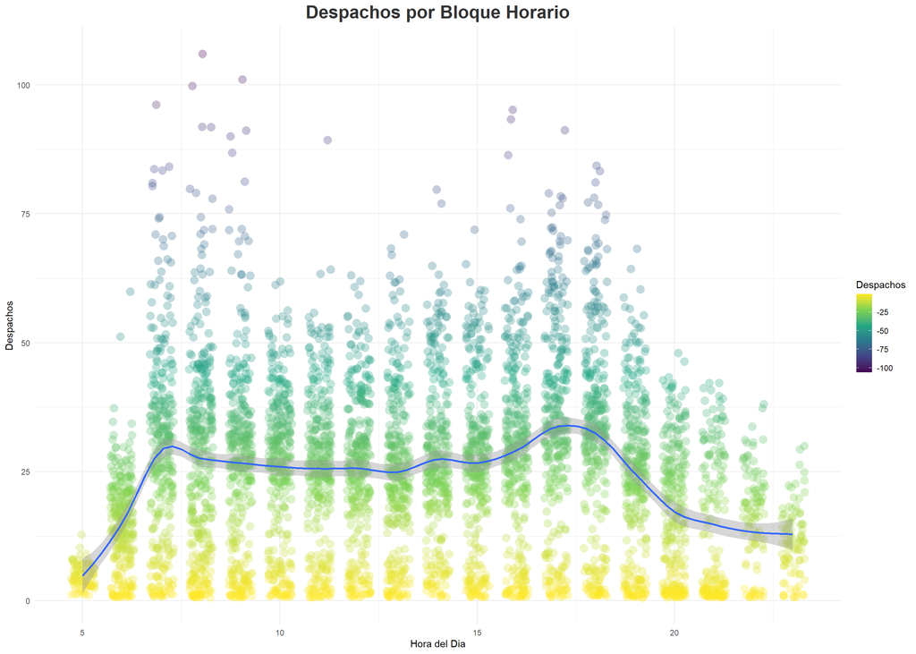

## ————————————————————————————-

#### **Comportamiento Horario por Dia de la Semana**

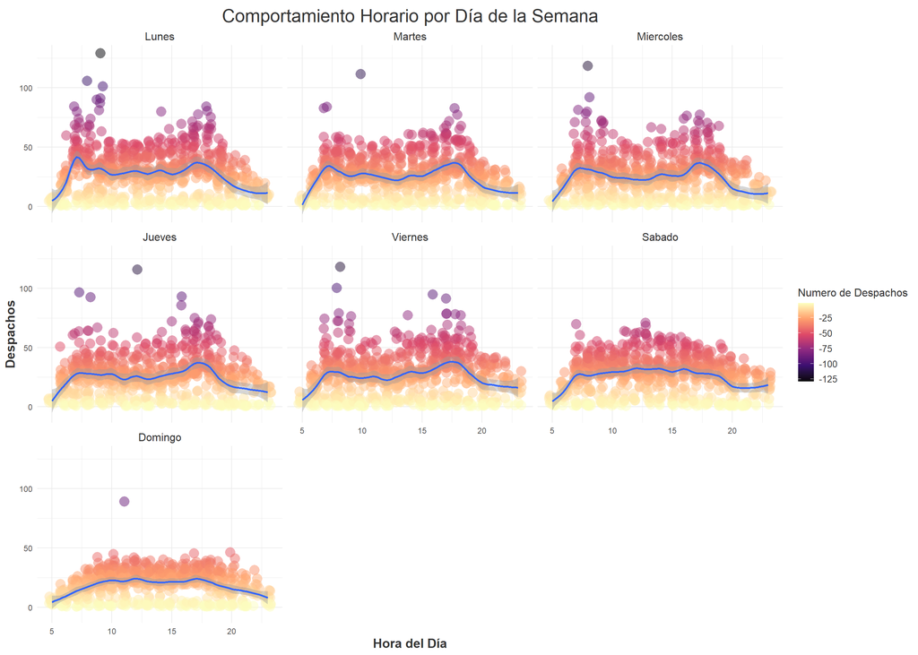

## ————————————————————————————-

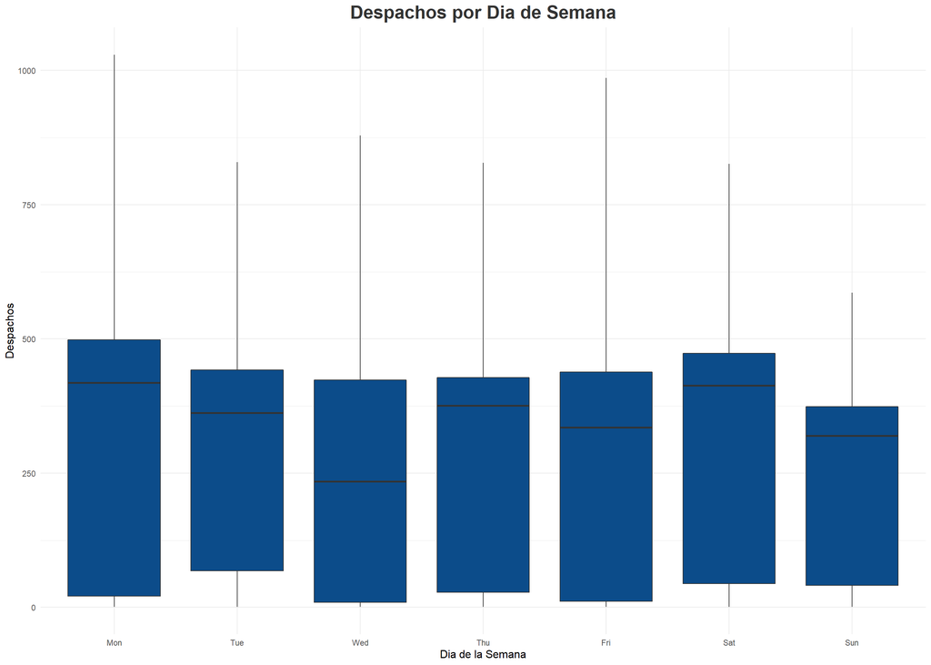

## ————————————————————————————-

## **V. Perfil de Clientes**

#### **Tabla de Comportamiento de Clientes**

| Estacion | ID Cliente | Nombre del Cliente | Año ID | Categoría | Fecha | Visitas | Facturado |
| --- | --- | --- | --- | --- | --- | --- | --- |
| Luisiana | 00008008192246 | ORLANDO CABRERA | 8008 | Individuo | 2020-11-01 | 1 | 1150 |
| Luisiana | 01011953008439 | WILFREDO REYES | 1953 | Individuo | 2020-10-01 | 1 | 500 |
| Luisiana | 01011964010333 | RAFAEL LANDAVERDE | 1964 | Individuo | 2020-08-01 | 1 | 200 |
| Luisiana | 01011964010333 | RAFAEL LANDAVERDE | 1964 | Individuo | 2020-09-01 | 2 | 1500 |
| Luisiana | 01011964010333 | TRANSPORTE GASH | 1964 | Organizacion | 2020-10-01 | 1 | 3170 |
| Luisiana | 01011964010333 | TRANSPORTE SALGADO. | 1964 | Organizacion | 2020-10-01 | 1 | 200 |
| Luisiana | 01011972002118 | JOSE ARMANDO VELASQUE | 1972 | Individuo | 2020-11-01 | 1 | 300 |
| Luisiana | 01011973020077 | CARLOS PAZ CHAVEZ | 1973 | Individuo | 2021-03-01 | 1 | 80.01 |
| Luisiana | 01011975001902 | CELIA MARIA TEJEDA NAVAS | 1975 | Individuo | 2020-08-01 | 1 | 800.12 |
| Luisiana | 01011975001902 | CELIA MARIA TEJEDA NAVAS | 1975 | Individuo | 2020-11-01 | 1 | 1200 |

[output cut: 8970 more lines]

## ————————————————————————————-

## **VI. Que sigue?**

#### Data de otras estaciones.

#### Data historica completa.

#### Data de tipo de combustible, galones despachados, credito o contado, precio del combustible en fecha de despacho.

#### Estimación burda de edad de clientes individuales.

#### Estimación de Sexo del Cliente.

#### Analisis de Serie de Tiempo y Descomposición de Tendencia.